# Group 9 Presentation

Heart Disease Classification

Henrique Magalhaes Rio , Oriana Meldrum, Jorie Alvis

12/8/2021

# Introduction

In 2019 659,041 Americans died of heart disease. Four out of five heart disease deaths are due to heart attacks and strokes, and one-third of these deaths occur prematurely in people under 70 years of age. Heart failure is a common event caused by heart disease and this dataset we used contains 11 variables that can be used to predict a possible heart disease.

People with cardiovascular disease or who are at high cardiovascular risk (due to the presence of one or more risk factors) need early detection and management so machine learning techniques are of great clinical intrest for early detection.

(https://www.cdc.gov/nchs/fastats/leading-causes-of-death.htm, https://www.kaggle.com/fedesoriano/heart-failure-prediction)

# Data

++ TA: Typical Angina

++ ATA: Atypical Angina

++ NAP: Non-Anginal Pain

++ ASY: Asymptomatic

- Resting Blood Pressure [mm Hg]
- Cholesterol [mm/dl]
- Fasting Blood Sugar Y/N

# Data

- Resting Electrocardiogram

++ Normal: Normal

++ ST: Having ST-T Wave abnormality

++ LVH: Showing probable or definite left ventricular hypertrophy.

- Max HR: Maximum heart rate achieved.
- Exercise Angina: exercise-induced angine Y/N
- Old peak: Oldpeak= ST value of depression
- ST_Slope (Slope of the peak exercise ST segment):

++ Up sloping(up)

++ Flat(flat)

++ Down sloping (down)

- Heart Disease: [1:Heart Disease, 0: Normal]

# Logistic Regression

```
##
## Call:
## glm(formula = HeartDisease ~ ., family = "binomial", data = train)
##
## Deviance Residuals:
##     Min       1Q   Median       3Q      Max
## -2.6823  -0.3298   0.1593   0.4214   2.6144
##
## Coefficients:
##                   Estimate Std. Error z value Pr(>|z|)
## (Intercept)      -0.688185   1.814047  -0.379  0.70442
## Age               0.019083   0.018443   1.035  0.30081
## SexM              1.449234   0.363402   3.988 6.66e-05 ***
## ChestPainTypeATA -2.200799   0.415679  -5.294 1.19e-07 ***
## ChestPainTypeNAP -2.294483   0.378043  -6.069 1.28e-09 ***
## ChestPainTypeTA  -1.468140   0.617820  -2.376  0.01749 *
## RestingBP        -0.002964   0.008709  -0.340  0.73361
## Cholesterol      -0.004616   0.001424  -3.241  0.00119 **
## FastingBS1        1.218883   0.374243   3.257  0.00113 **
## RestingECGNormal -0.125716   0.359027  -0.350  0.72622
## RestingECGST     -0.306034   0.479711  -0.638  0.52350
## MaxHR             0.001609   0.006653   0.242  0.80896
## ExerciseAnginaY   0.953829   0.337967   2.822  0.00477 **
## Oldpeak           0.315591   0.165962   1.902  0.05723 .
## ST_SlopeFlat      1.470516   0.565530   2.600  0.00932 **
## ST_SlopeUp       -1.189753   0.597455  -1.991  0.04644 *
## ---
## Signif. codes:  0 '***' 0.001 '**' 0.01 '*' 0.05 '.' 0.1 ' ' 1
##
## (Dispersion parameter for binomial family taken to be 1)
##
##     Null deviance: 754.15  on 550  degrees of freedom
## Residual deviance: 335.54  on 535  degrees of freedom
## AIC: 367.54
##
## Number of Fisher Scoring iterations: 6
```

|  | 0 | 1 |
| --- | --- | --- |
| 0 | 136 | 20 |
| 1 | 35 | 176 |

```
## [1] "Accuracy : 0.850136239782016"
```

# LDA

```
##      True
## Preds   0   1
##     0 138  20
##     1  33 176
```

```
## [1] 0.8555858
```

```
## Call:
## lda(HeartDisease ~ ., data = train)
##
## Prior probabilities of groups:
##         0         1
## 0.4337568 0.5662432
##
## Group means:
##        Age      SexM ChestPainTypeATA ChestPainTypeNAP ChestPainTypeTA
## 0 50.34310 0.6359833       0.37656904        0.3305439      0.05020921
## 1 55.67308 0.8878205       0.04807692        0.1217949      0.04166667
##   RestingBP Cholesterol FastingBS1 RestingECGNormal RestingECGST    MaxHR
## 0  130.1088    225.8577  0.1046025        0.6359833    0.1506276 150.2050
## 1  133.7147    178.8462  0.3205128        0.5769231    0.1955128 127.7276
##   ExerciseAnginaY   Oldpeak ST_SlopeFlat ST_SlopeUp
## 0        0.125523 0.3974895    0.1841004  0.7782427
## 1        0.625000 1.2467949    0.7628205  0.1506410
##
## Coefficients of linear discriminants:
##                            LD1
## Age               0.0097004227
## SexM              0.6347331404
## ChestPainTypeATA -1.2381070900
## ChestPainTypeNAP -1.1851491518
## ChestPainTypeTA  -0.6753130586
## RestingBP        -0.0009882450
## Cholesterol      -0.0021443061
## FastingBS1        0.5252252999
## RestingECGNormal -0.0355744966
## RestingECGST     -0.0835470224
## MaxHR             0.0004668529
## ExerciseAnginaY   0.5605434782
## Oldpeak           0.1780991082
## ST_SlopeFlat      0.7064569196
## ST_SlopeUp       -0.8582220592
```

# KNN

```
## [1] 0.6757493
```

|  | 0 | 1 |
| --- | --- | --- |
| 0 | 93 | 41 |
| 1 | 78 | 155 |

```
## [1] 0.3242507
```

# LASSO

```
## [1] "Tuning Lambda 0.00626936793624135"
```

```
##          True
## predicted   0   1
##         0 147  30
##         1  24 166
```

|  | 0 | 1 |
| --- | --- | --- |
| 0 | 147 | 30 |
| 1 | 24 | 166 |

```
## [1] 0.852861
```

# Bagging

|  | 0 | 1 |
| --- | --- | --- |
| 0 | 138 | 24 |
| 1 | 33 | 172 |

```
## [1] 0.8446866
```

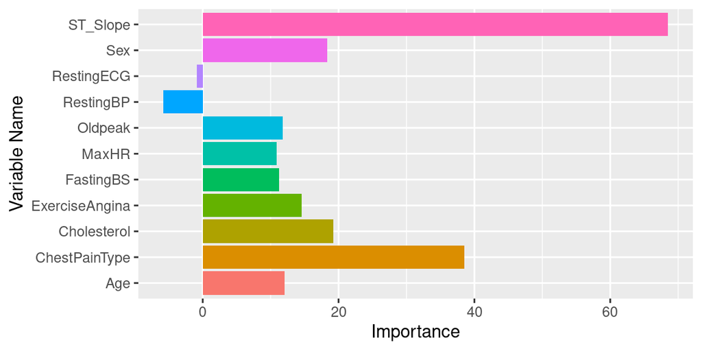

# Random Forest

```
##          True
## predicted   0   1
##         0 138  17
##         1  33 179
```

```
## [1] "Accuracy : 0.863760217983651"
```

```
##
## Call:
##  randomForest(formula = as.factor(HeartDisease) ~ ., data = train,      mtry = sqrt(ncol(train) - 1), importance = TRUE, type = "classification")
##                Type of random forest: classification
##                      Number of trees: 500
## No. of variables tried at each split: 3
##
##         OOB estimate of  error rate: 13.61%
## Confusion matrix:
##     0   1 class.error
## 0 195  44  0.18410042
## 1  31 281  0.09935897
```

# Random Forest Plot

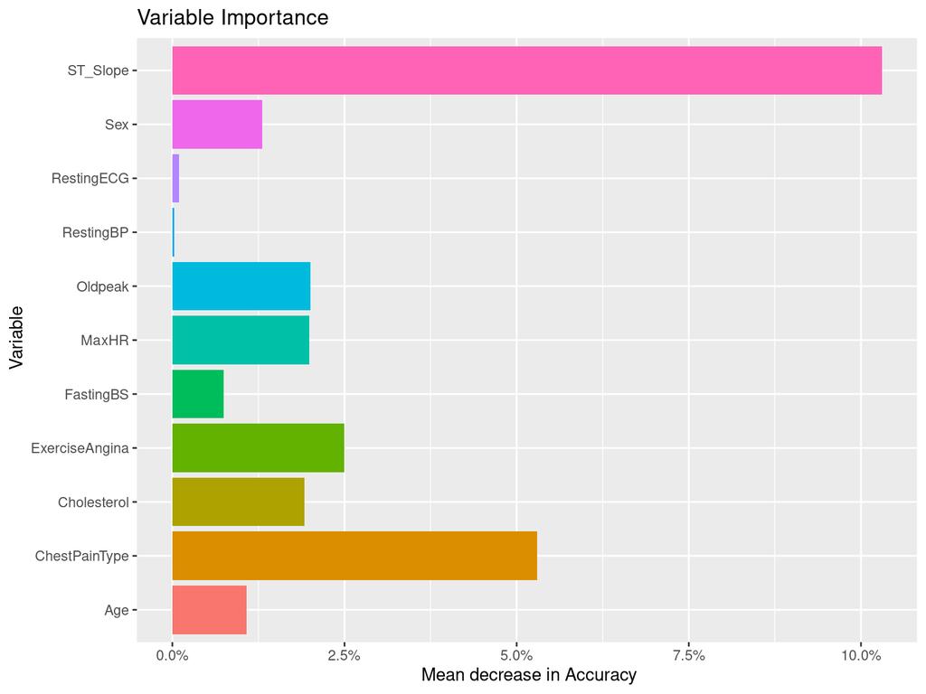

# Representative Tree

- Following the paper “Identifying representative Trees From Ensembles” by Banerjee, et al.(2011) and the package reprtree we can get a representative tree from the random forest.
- This tree is calculated using a measure of similarity, in which 2 trees are similar if they have the same prediction for all observations.
- The representative tree is then choosen based on its averaged similarity between all other trees.
- Using this idea on the random forest we get the following tree:

# Representative Tree Plot

```
## [1] "Constructing distance matrix..."
## [1] "Finding representative trees..."
```

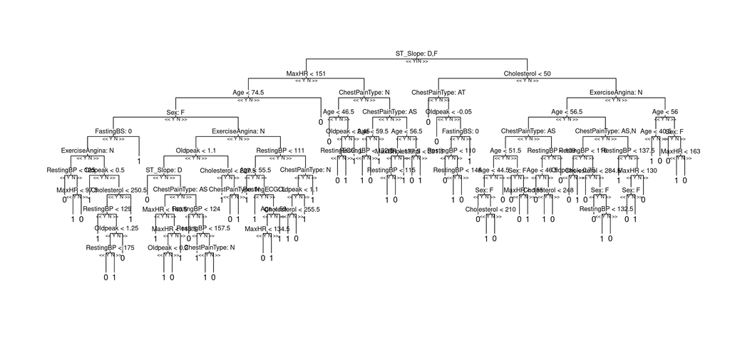

# Boosting

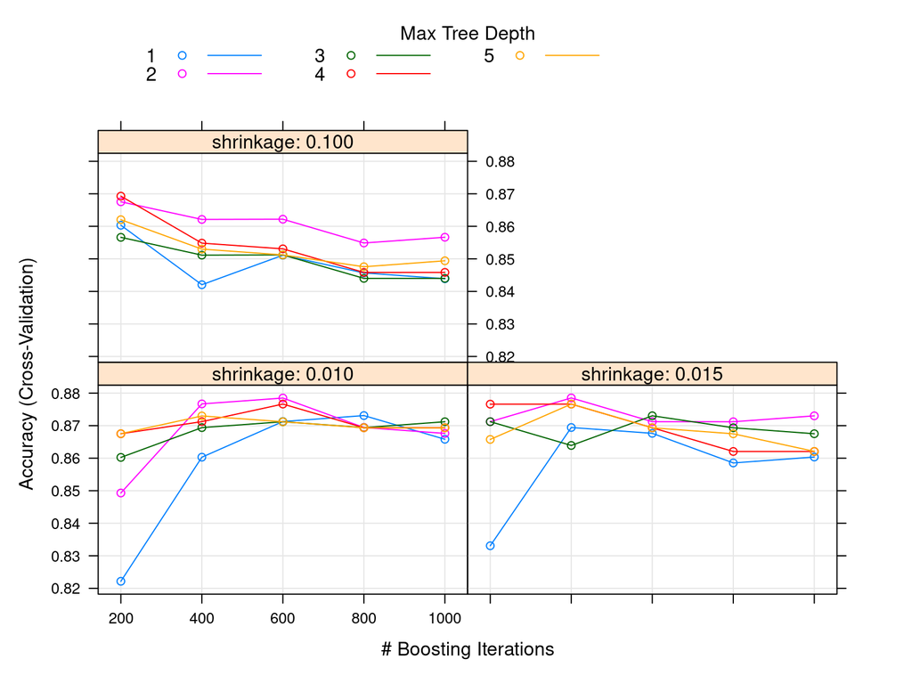

- Tuning Parameters: n= 600 trees, shrinkage=0.01, interaction= 2.

```
##          actual
## predicted   0   1
##         0 143  15
##         1  28 181
```

```
## [1] 0.8828338
```

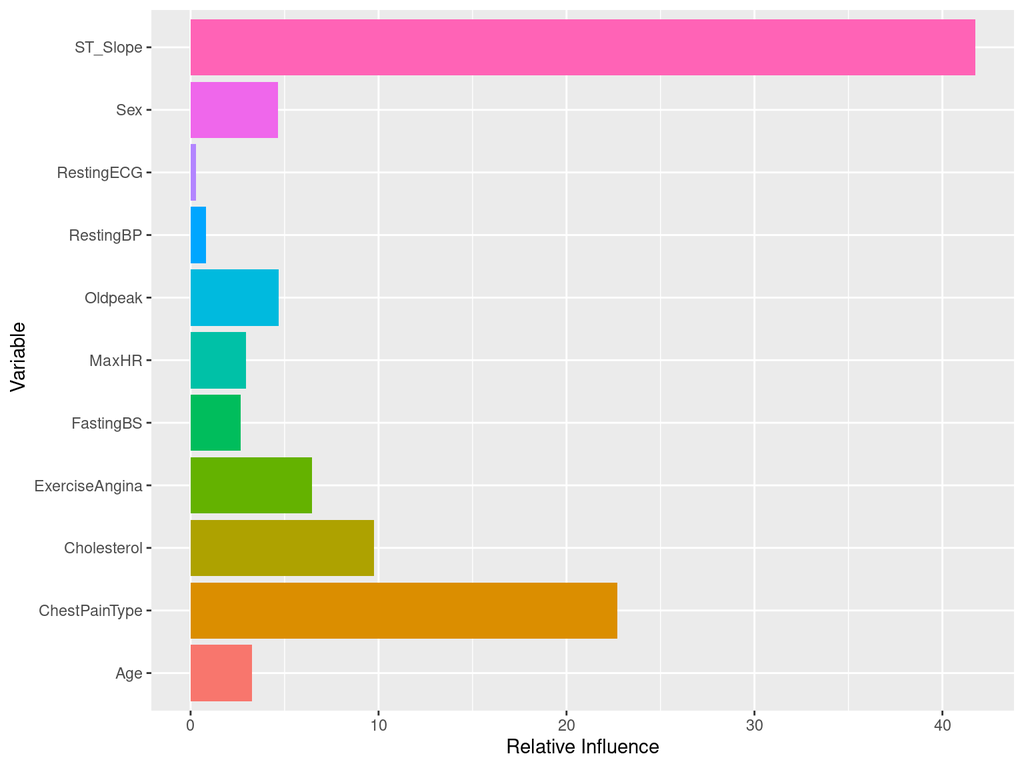

# SVM

```
##     Linear Svm Polynomial Svm     Radial SVM
##      0.8501362      0.8583106      0.8692098
```

- Confusion Matrix for Radial Kernel:

```
##    preds_radial
##       0   1
##   0 136  35
##   1  13 183
```

# Results

- What method would be the best?

| Method | Accuracy |
| --- | --- |
| Logistic Regression | 0.8501362 |
| LDA | 0.8555858 |
| KNN | 0.6757493 |
| LASSO | 0.8528610 |
| Bagging | 0.8446866 |
| Random Forest | 0.8637602 |
| Boosting | 0.8828338 |
| SVM | 0.8692098 |